# Re-assessing of R/F results plus power analysis attempt

## Mixed models

Preparing and recoding the data for mixed effects analysis.

```r
####################################
# Code for recollection, familiarity and guess
# Recollection
# Recall
recollectionRecall               <- rep(0, length(dataSchemaVR2$recallMemory))
recollectionRecall[dataSchemaVR2$recallMemory == 1]   <- 1
recollectionRecall[is.na(dataSchemaVR2$recallMemory)] <- NA
recollectionRecall               <- as.factor(recollectionRecall)
levels(recollectionRecall)       <- c('not recollected', 'recollected')
dataSchemaVR2$recollectionRecall <- recollectionRecall

# 3AFc
recollection3AFC               <- rep(0, length(dataSchemaVR2$resCon))
recollection3AFC[dataSchemaVR2$resCon == 1] <- 1
recollection3AFC[is.na(dataSchemaVR2$resCon)] <- NA
recollection3AFC               <- as.factor(recollection3AFC)
levels(recollection3AFC)       <- c('not recollected', 'recollected')
dataSchemaVR2$recollection3AFC <- recollection3AFC

####################################
# Familiarity
# Recall
familiarityRecall               <- rep(0, length(dataSchemaVR2$recallMemory))
familiarityRecall[dataSchemaVR2$recallMemory == 2]   <- 1
familiarityRecall[is.na(dataSchemaVR2$recallMemory)] <- NA
familiarityRecall               <- as.factor(familiarityRecall)
levels(familiarityRecall)       <- c('not familiar', 'familiar')
dataSchemaVR2$familiarityRecall <- familiarityRecall

# 3AFC
familiarity3AFC               <- rep(0, length(dataSchemaVR2$resCon))
familiarity3AFC[dataSchemaVR2$resCon == 2]   <- 1
familiarity3AFC[is.na(dataSchemaVR2$resCon)] <- NA
familiarity3AFC               <- as.factor(familiarity3AFC)
levels(familiarity3AFC)       <- c('not familiar', 'familiar')
dataSchemaVR2$familiarity3AFC <- familiarity3AFC

####################################
# Guess
# Recall
guessRecall               <- rep(0, length(dataSchemaVR2$recallMemory))
guessRecall[dataSchemaVR2$recallMemory == 3]   <- 1
guessRecall[is.na(dataSchemaVR2$recallMemory)] <- NA
guessRecall               <- as.factor(guessRecall)
levels(guessRecall)       <- c('not guessed', 'guessed')
dataSchemaVR2$guessRecall <- guessRecall

# 3AFC
guess3AFC               <- rep(0, length(dataSchemaVR2$resCon))
guess3AFC[dataSchemaVR2$resCon == 3]   <- 1
guess3AFC[is.na(dataSchemaVR2$resCon)] <- NA
guess3AFC               <- as.factor(guess3AFC)
levels(guess3AFC)       <- c('not guessed', 'guessed')
dataSchemaVR2$guess3AFC <- guess3AFC
```

In the models below, I model every response (present vs. not present) for each trial as a function of object/location memory corrected for the objects’ general expectancy. As random effects, intercept for each object and for participants are added. Note that the indenpendent variables are standardised (centered and scaled by SD).

```r
####################################
# Models
# Recollection
# Recall
schemaVR2_rf_model1 <- glmer(recollectionRecall ~  scale(objLocTargetRating)  +
                             scale(generalRatingPost) +
                             (1 | subNum) +
                             (1 | objNum),
                           data = dataSchemaVR2,
                           family = binomial,
                           control = glmerControl(optimizer = "bobyqa"),
                           nAGQ = 1)

createResultTable(schemaVR2_rf_model1)
```

```
##                           Estimate   SE     Z      P Sig
## (Intercept)                  -0.43 0.26 -1.64 0.1000   .
## scale(objLocTargetRating)     0.27 0.13  2.11 0.0350   *
## scale(generalRatingPost)      0.19 0.17  1.13 0.2591
```

```r
# 3AFC
schemaVR2_rf_model2 <- glmer(recollection3AFC ~  scale(objLocTargetRating) +
                             scale(generalRatingPost) +
                             (1 | subNum) +
                             (1 | objNum),
                           data = dataSchemaVR2,
                           family = binomial,
                           control = glmerControl(optimizer = "bobyqa"),
                           nAGQ = 1)

createResultTable(schemaVR2_rf_model2)
```

```
##                           Estimate   SE     Z      P Sig
## (Intercept)                  -0.32 0.25 -1.25 0.2127
## scale(objLocTargetRating)     0.22 0.13  1.72 0.0859   .
## scale(generalRatingPost)      0.15 0.16  0.92 0.3601
```

As can be seen above, for both the recall task and the 3AFC task we have postive relationship between object/location expectancy and recolllection when general expectancy is controlled for. This is in stark contrast with results from the correlational analysis.

For the sake of completeness, see below for the other models.

```r
####################################
# Familairity
# Recall
schemaVR2_rf_model3 <- glmer(familiarityRecall ~  objLocTargetRating  +
                             generalRatingPost +
                             (1 | subNum) +
                             (1 | objNum),
                           data = dataSchemaVR2,
                           family = binomial,
                           control = glmerControl(optimizer = "bobyqa"),
                           nAGQ = 1)

createResultTable(schemaVR2_rf_model3)
```

```
##                    Estimate   SE     Z      P Sig
## (Intercept)           -1.43 0.22 -6.52 0.0000 ***
## objLocTargetRating     0.00 0.00 -0.31 0.7593
## generalRatingPost      0.00 0.00 -1.36 0.1733
```

```r
# 3AFc
schemaVR2_rf_model4 <- glmer(familiarity3AFC ~  objLocTargetRating  +
                             generalRatingPost +
                             (1 | subNum) +
                             (1 | objNum),
                           data = dataSchemaVR2,
                           family = binomial,
                           control = glmerControl(optimizer = "bobyqa"),
                           nAGQ = 1)

createResultTable(schemaVR2_rf_model4)
```

```
##                    Estimate   SE     Z      P Sig
## (Intercept)           -1.16 0.17 -6.98 0.0000 ***
## objLocTargetRating     0.00 0.00  1.26 0.2089
## generalRatingPost      0.00 0.00 -1.49 0.1360
```

```r
####################################
# Guess
schemaVR2_rf_model5 <- glmer(guessRecall ~  objLocTargetRating  +
                             generalRatingPost ++
                             (1 | subNum) +
                             (1 | objNum),
                           data = dataSchemaVR2,
                           family = binomial,
                           control = glmerControl(optimizer = "bobyqa"),
                           nAGQ = 1)

createResultTable(schemaVR2_rf_model5)
```

```
##                    Estimate   SE     Z      P Sig
## (Intercept)           -1.36 0.24 -5.65 0.0000 ***
## objLocTargetRating     0.00 0.00  0.79 0.4291
## generalRatingPost      0.00 0.00 -0.45 0.6518
```

```r
# 3AFc
schemaVR2_rf_model6 <- glmer(guess3AFC ~  objLocTargetRating  +
                             generalRatingPost +
                             (1 | subNum) +
                             (1 | objNum),
                           data = dataSchemaVR2,
                           family = binomial,
                           control = glmerControl(optimizer = "bobyqa"),
                           nAGQ = 1)

createResultTable(schemaVR2_rf_model6)
```

```
##                    Estimate   SE     Z      P Sig
## (Intercept)           -1.44 0.21 -6.95 0.0000 ***
## objLocTargetRating     0.00 0.00 -0.70 0.4814
## generalRatingPost      0.00 0.00  1.24 0.2140
```

# Understanding the disparity

Here, I try to understand the disparity between the correlational analysis and the result of the mixed models analysis by exploring and visualising the data.

## Aggregate by recollection

To do this, I compare the average expectancy when a participant gave a remember response versus any other response. The problem with this approach might be that this includes all the other responses (no memory, guess and familiar). I do the same for objects, so comparing the average expectancy when an object’s location was recollected. The motivation was to see whether a Simpson’s paradox situation might drive our results.

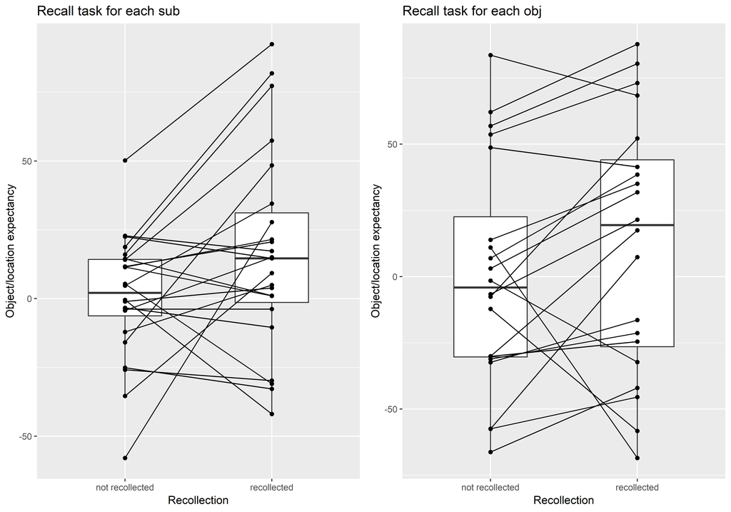

```r
####################################
# Recall
# Across subjects
recAgg_recall_sub  <- ddply(na.omit(dataSchemaVR2),
                            c('subNum','recollectionRecall'),
                            summarise,
                            objLocTargetRating = mean(objLocTargetRating, na.rm = TRUE))


recAgg_recall_sub_plot <- ggplot(recAgg_recall_sub,
                                 aes(x = recollectionRecall, y = objLocTargetRating)) +
  geom_boxplot(width = 0.5) +
  geom_point() +
  geom_line(aes(group = subNum)) +
  labs(title = 'Recall task for each sub',
       y = 'Object/location expectancy',
       x = "Recollection")

# Across objects
recAgg_recall_obj  <- ddply(na.omit(dataSchemaVR2),
                            c('objNum','recollectionRecall'),
                            summarise,
                            objLocTargetRating = mean(objLocTargetRating, na.rm = TRUE))


recAgg_recall_obj_plot <- ggplot(recAgg_recall_obj,
                                 aes(x = recollectionRecall, y = objLocTargetRating)) +
  geom_boxplot(width = 0.5) +
  geom_point() +
  geom_line(aes(group = objNum)) +
  labs(title = 'Recall task for each obj',
       y = 'Object/location expectancy',
       x = "Recollection")

# Plot both
recAgg_recall_plot <- grid.arrange(recAgg_recall_sub_plot,
                        recAgg_recall_obj_plot,
                        ncol = 2)
```

```r
## Figure: This plot was created with ggplot2. Both plots in the panel show a boxplot for a factor with two levels where the individual datapoints are included and connected across the measuring unit to indicate the intra-unit change across the factor, which is either subjects or objects.

# Test both effects
t.test(objLocTargetRating ~ recollectionRecall, recAgg_recall_sub)
```

```
##
##  Welch Two Sample t-test
##
## data:  objLocTargetRating by recollectionRecall
## t = -1.7812, df = 36.113, p-value = 0.0833
## alternative hypothesis: true difference in means is not equal to 0
## 95 percent confidence interval:
##  -33.673999   2.180905
## sample estimates:
## mean in group not recollected     mean in group recollected
##                     0.7435031                    16.4900502
```

```r
t.test(objLocTargetRating ~ recollectionRecall, recAgg_recall_obj)
```

```
##
##  Welch Two Sample t-test
##
## data:  objLocTargetRating by recollectionRecall
## t = -0.82769, df = 37.442, p-value = 0.4131
## alternative hypothesis: true difference in means is not equal to 0
## 95 percent confidence interval:
##  -41.19692  17.29403
## sample estimates:
## mean in group not recollected     mean in group recollected
##                     0.3511044                    12.3025522
```

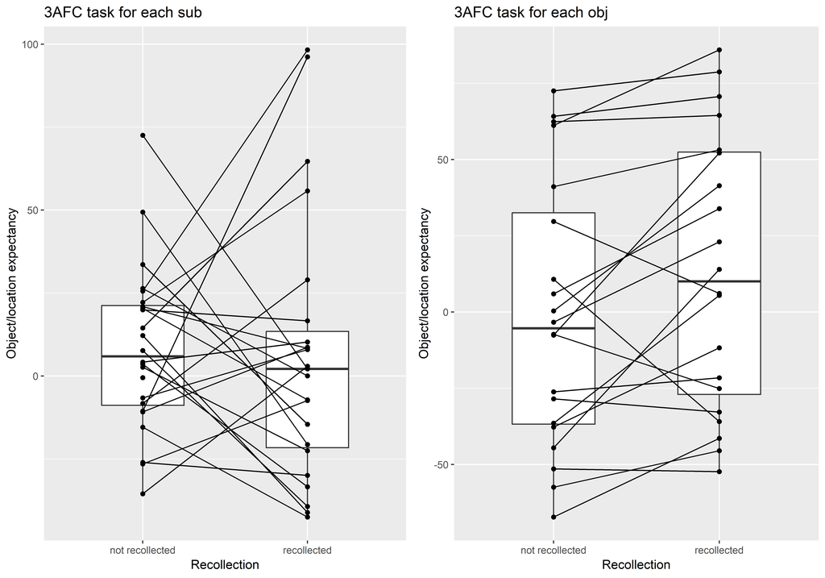

```r
####################################
# 3AFC
# Across subjects
recAgg_AFC_sub  <- ddply(na.omit(dataSchemaVR2),
                            c('subNum','recollection3AFC'),
                            summarise,
                            objLocTargetRating = mean(objLocTargetRating, na.rm = TRUE))


recAgg_AFC_sub_plot <- ggplot(recAgg_AFC_sub,
                              aes(x = recollection3AFC, y = objLocTargetRating)) +
  geom_boxplot(width = 0.5) +
  geom_point() +
  geom_line(aes(group = subNum)) +
  labs(title = '3AFC task for each sub',
       y = 'Object/location expectancy',
       x = "Recollection")

# Across objects
recAgg_AFC_obj  <- ddply(na.omit(dataSchemaVR2),
                            c('objNum','recollection3AFC'),
                            summarise,
                            objLocTargetRating = mean(objLocTargetRating, na.rm = TRUE))


recAgg_AFC_obj_plot <- ggplot(recAgg_AFC_obj,
                              aes(x = recollection3AFC, y = objLocTargetRating)) +
  geom_boxplot(width = 0.5) +
  geom_point() +
  geom_line(aes(group = objNum)) +
  labs(title = '3AFC task for each obj',
       y = 'Object/location expectancy',
       x = "Recollection")


# Plot both
recAgg_AFC_plot <- grid.arrange(recAgg_AFC_sub_plot,
                        recAgg_AFC_obj_plot,
                        ncol = 2)
```

```r
## Figure: This plot was created with ggplot2. Both plots in the panel show a boxplot for a factor with two levels where the individual datapoints are included and connected across the measuring unit to indicate the intra-unit change across the factor, which is either subjects or objects.

# Test both effects
t.test(objLocTargetRating ~ recollection3AFC, recAgg_AFC_sub)
```

```
##
##  Welch Two Sample t-test
##
## data:  objLocTargetRating by recollection3AFC
## t = 0.20027, df = 36.384, p-value = 0.8424
## alternative hypothesis: true difference in means is not equal to 0
## 95 percent confidence interval:
##  -17.78183  21.68004
## sample estimates:
## mean in group not recollected     mean in group recollected
##                      8.132395                      6.183288
```

```r
t.test(objLocTargetRating ~ recollection3AFC, recAgg_AFC_obj)
```

```
##
##  Welch Two Sample t-test
##
## data:  objLocTargetRating by recollection3AFC
## t = -1.0034, df = 37.971, p-value = 0.322
## alternative hypothesis: true difference in means is not equal to 0
## 95 percent confidence interval:
##  -42.59382  14.36295
## sample estimates:
## mean in group not recollected     mean in group recollected
##                     -0.983476                     13.131956
```

For the 3AFC task, it looks different when aggregated by subjects and objects. Interestingly, the subject approach looks similar to the correlational analysis. It is puzzling that aggregating by objects gives a different result than the correlational analysis because the correlational is also based on objects.